# Practical Machine Learning - Project

## Introduction

In this project, we are going to use Human Activity Recognition (HAR) data on accelerometers on the belt, forearm, arm and dumbell of 6 participants to predict the way they will perform various weight lifting exercise - based on the signals captured by wearable movement sensors.

In particular, a random forest model is developed to address this issue. Data for this project originated from the website here: http://groupware.les.inf.puc-rio.br/har (see the section on the Weight Lifting Exercise Dataset).

## Data Loading

Load relevant libraries:

```r
library(caret);library(randomForest)
```

Download training and testing datasets:

```r
# setwd() set your working directory

if(!file.exists("./data")){dir.create("./data")}

trainUrl= "https://d396qusza40orc.cloudfront.net/predmachlearn/pml-training.csv"
testUrl= "https://d396qusza40orc.cloudfront.net/predmachlearn/pml-testing.csv"

download.file(trainUrl, destfile = "./data/pml-training.csv",method ="curl")
download.file(testUrl, destfile = "./data/pml-testing.csv",method ="curl")
```

Read data:

```r
trainData = read.csv('./data/pml-training.csv',header=TRUE,na.strings=c("NA","#DIV/0!", ""))
testData = read.csv('./data/pml-testing.csv',header=TRUE,na.strings=c("NA","#DIV/0!", ""))
```

```r
str(trainData);str(testData)
```

```
## 'data.frame':    19622 obs. of  160 variables:
##  $ X                       : int  1 2 3 4 5 6 7 8 9 10 ...
##  $ user_name               : Factor w/ 6 levels "adelmo","carlitos",..: 2 2 2 2 2 2 2 2 2 2 ...
##  $ raw_timestamp_part_1    : int  1323084231 1323084231 1323084231 1323084232 1323084232 1323084232 1323084232 1323084232 1323084232 1323084232 ...
##  $ raw_timestamp_part_2    : int  788290 808298 820366 120339 196328 304277 368296 440390 484323 484434 ...
##  $ cvtd_timestamp          : Factor w/ 20 levels "02/12/2011 13:32",..: 9 9 9 9 9 9 9 9 9 9 ...
##  $ new_window              : Factor w/ 2 levels "no","yes": 1 1 1 1 1 1 1 1 1 1 ...
##  $ num_window              : int  11 11 11 12 12 12 12 12 12 12 ...
##  $ roll_belt               : num  1.41 1.41 1.42 1.48 1.48 1.45 1.42 1.42 1.43 1.45 ...
##  $ pitch_belt              : num  8.07 8.07 8.07 8.05 8.07 8.06 8.09 8.13 8.16 8.17 ...
##  $ yaw_belt                : num  -94.4 -94.4 -94.4 -94.4 -94.4 -94.4 -94.4 -94.4 -94.4 -94.4 ...
##  $ total_accel_belt        : int  3 3 3 3 3 3 3 3 3 3 ...
##  $ kurtosis_roll_belt      : num  NA NA NA NA NA NA NA NA NA NA ...
##  $ kurtosis_picth_belt     : num  NA NA NA NA NA NA NA NA NA NA ...
##  $ kurtosis_yaw_belt       : logi  NA NA NA NA NA NA ...
```

[output cut: 86 more lines]

```
## 'data.frame':    20 obs. of  160 variables:
##  $ X                       : int  1 2 3 4 5 6 7 8 9 10 ...
##  $ user_name               : Factor w/ 6 levels "adelmo","carlitos",..: 6 5 5 1 4 5 5 5 2 3 ...
##  $ raw_timestamp_part_1    : int  1323095002 1322673067 1322673075 1322832789 1322489635 1322673149 1322673128 1322673076 1323084240 1322837822 ...
##  $ raw_timestamp_part_2    : int  868349 778725 342967 560311 814776 510661 766645 54671 916313 384285 ...
##  $ cvtd_timestamp          : Factor w/ 11 levels "02/12/2011 13:33",..: 5 10 10 1 6 11 11 10 3 2 ...
##  $ new_window              : Factor w/ 1 level "no": 1 1 1 1 1 1 1 1 1 1 ...
##  $ num_window              : int  74 431 439 194 235 504 485 440 323 664 ...
##  $ roll_belt               : num  123 1.02 0.87 125 1.35 -5.92 1.2 0.43 0.93 114 ...
##  $ pitch_belt              : num  27 4.87 1.82 -41.6 3.33 1.59 4.44 4.15 6.72 22.4 ...
##  $ yaw_belt                : num  -4.75 -88.9 -88.5 162 -88.6 -87.7 -87.3 -88.5 -93.7 -13.1 ...
##  $ total_accel_belt        : int  20 4 5 17 3 4 4 4 4 18 ...
##  $ kurtosis_roll_belt      : logi  NA NA NA NA NA NA ...
##  $ kurtosis_picth_belt     : logi  NA NA NA NA NA NA ...
##  $ kurtosis_yaw_belt       : logi  NA NA NA NA NA NA ...
```

[output cut: 86 more lines]

The training data set contains 19622 observations and 160 variables, while the testing data set contains 20 observations and 160 variables. The outcome variable that needs to be predicted is the “classe” variable in the training set

## Data Preprocessing

In this section, we are going to perform some basic data preprocessing.

Removing NA variables:

```r
trainData = trainData[, colSums(is.na(trainData)) == 0]
testData = testData[, colSums(is.na(testData)) == 0]
```

Removing irrelevant variables - that do not contribute much to the accelerometer measurements:

```r
trainData = trainData[, !grepl("^X|timestamp|window|user_name", names(trainData))]
testData = testData[, !grepl("^X|timestamp|window|user_name", names(testData))]
```

Converting variable type to numeric - with the exception of the “classe” variable, that is factor type:

```r
for (i in c(2:ncol(trainData)-1)) {

        trainData[,i] = as.numeric(as.character(trainData[,i]))
        testData[,i] = as.numeric(as.character(testData[,i]))
}
```

Check for zero and near-zero variance variables:

```r
zeroVar = nearZeroVar(trainData, saveMetrics = TRUE)
zeroVar[, (zeroVar$zeroVar == TRUE | zeroVar$nzv == TRUE)]
```

```
## data frame with 0 columns and 53 rows
```

No variables are detected as having zero or near-zero variance.

```r
dim(trainData);dim(testData)
```

```
## [1] 19622    53
```

```
## [1] 20 53
```

Our training dataset now contains 19622 observations and 53 variables, while the testing data set contains 20 observations and 53 variables.

## Data Slicing

The study design requires a cross validation set. Therefore, the trainData dataset is partitioned into two subsamples: a training data set (70%) and a validation data set (30%).

```r
set.seed(22519)  # set the seed for reproducibility

inTrain = createDataPartition(y=trainData$classe, p=0.70, list=FALSE)
training = trainData[inTrain, ]
validation = trainData[-inTrain, ]

dim(training);dim(validation)
```

```
## [1] 13737    53
```

```
## [1] 5885   53
```

## Building Random Forests Model

```r
model.Rf$finalModel
```

[output not shown]

```
##
## Call:
##  randomForest(x = x, y = y, ntree = 250, mtry = param$mtry)
##                Type of random forest: classification
##                      Number of trees: 250
## No. of variables tried at each split: 27
##
##         OOB estimate of  error rate: 0.72%
## Confusion matrix:
##      A    B    C    D    E class.error
## A 3901    3    2    0    0 0.001280082
## B   21 2628    8    1    0 0.011286682
## C    0   13 2376    7    0 0.008347245
## D    0    1   25 2224    2 0.012433393
## E    0    2    4   10 2509 0.006336634
```

With the varImp() function we can identify the importance of each of the 52 predictors in explaining our model:

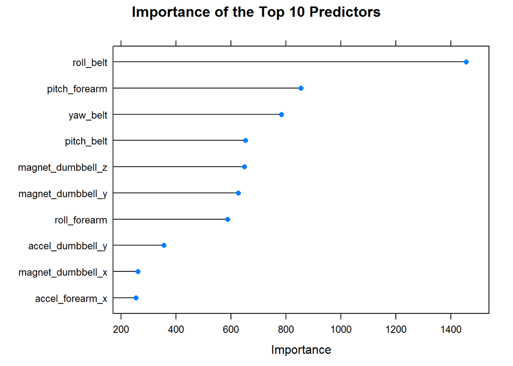

```r
Rf.imp = varImp(model.Rf, scale = FALSE)
plot(Rf.imp, top=10, main = "Importance of the Top 10 Predictors")
```

The plot shows that the 4 most important variables according to the model fit are “roll_belt”, “pitch_forearm”, “yaw_belt”, and “pitch_belt”.

## Cross - validation

Cross validation is performed by applying to the validation set the Random Forest model we developed on the training set. We use the predict() function to get predicted “classe” outcomes on the validation set.

```r
pred.Val = predict(model.Rf,validation)
confusionMatrix(validation$classe,pred.Val)
```

```
## Confusion Matrix and Statistics
##
##           Reference
## Prediction    A    B    C    D    E
##          A 1672    1    0    0    1
##          B    8 1127    4    0    0
##          C    0    1 1020    5    0
##          D    0    0   14  949    1
##          E    0    0    0    6 1076
##
## Overall Statistics
##
##                Accuracy : 0.993
##                  95% CI : (0.9906, 0.995)
##     No Information Rate : 0.2855
##     P-Value [Acc > NIR] : < 2.2e-16
##
##                   Kappa : 0.9912
##  Mcnemar's Test P-Value : NA
##
## Statistics by Class:
##
##                      Class: A Class: B Class: C Class: D Class: E
## Sensitivity            0.9952   0.9982   0.9827   0.9885   0.9981
## Specificity            0.9995   0.9975   0.9988   0.9970   0.9988
## Pos Pred Value         0.9988   0.9895   0.9942   0.9844   0.9945
## Neg Pred Value         0.9981   0.9996   0.9963   0.9978   0.9996
## Prevalence             0.2855   0.1918   0.1764   0.1631   0.1832
## Detection Rate         0.2841   0.1915   0.1733   0.1613   0.1828
## Detection Prevalence   0.2845   0.1935   0.1743   0.1638   0.1839
## Balanced Accuracy      0.9974   0.9979   0.9907   0.9927   0.9984
```

```r
accuracy.Val = confusionMatrix(validation$classe,pred.Val)$overall[1]
out_of_sample_error = 1 - accuracy.Val
print(cbind(accuracy.Val,out_of_sample_error))
```

```
##          accuracy.Val out_of_sample_error
## Accuracy    0.9930331         0.006966865
```

## Predicting on the Testing set

Once the model has been built, we apply our ML algorithm to predict the outcome variable for 20 different test cases available in the original testing dataset. The column names are not consistent between the test and training data, so we exclude the “problem_id” variable from the testing set.

```r
pred.Test = predict(model.Rf,testData[, -length(names(testData))])
pred.Test
```

```
##  [1] B A B A A E D B A A B C B A E E A B B B
## Levels: A B C D E
```

The vector pred.Test contains the 20 outcome predictions that are submitted for grading via the Coursera website with a separate process: it turns out that our RF model correctly predicts 20 cases out of 20 - confirming its strong predictive power.